# 2nd Kaggle korea - House Price Prediction

1. 데이터 로딩

```python
# 데이터 로딩
import pandas as pd

train = pd.read_csv('C:/Kaggle Korea/2019-2nd-ml-month-with-kakr/train.csv')
test = pd.read_csv('C:/Kaggle Korea/2019-2nd-ml-month-with-kakr/test.csv')
```

```python
print("train.csv. Shape: ",train.shape)
print("test.csv. Shape: ",test.shape)
# 약 15000개의 row와 예측하고자하는 price를 제외하고 20개의 columns 존재
```

```
train.csv. Shape:  (15035, 21)
test.csv. Shape:  (6468, 20)
```

```python
# 필요 라이브러리
import matplotlib.pyplot as plt
%matplotlib inline
import seaborn as sns
import numpy as np
```

1. 데이터셋 분석(Data Explore)

```python
# 각 필드에 따른 null값 분석
pd.DataFrame({'null_count' : train.isnull().sum()})
pd.DataFrame({'null_count' : test.isnull().sum()})
# 모든 변수에 결측치가 없으며, date를 제외한 나머지 columns은 numeric
```

|  | null_count |
| --- | --- |
| id | 0 |
| date | 0 |
| bedrooms | 0 |
| bathrooms | 0 |
| sqft_living | 0 |
| sqft_lot | 0 |
| floors | 0 |
| waterfront | 0 |
| view | 0 |
| condition | 0 |
| grade | 0 |
| sqft_above | 0 |
| sqft_basement | 0 |
| yr_built | 0 |
| yr_renovated | 0 |
| zipcode | 0 |
| lat | 0 |
| long | 0 |
| sqft_living15 | 0 |
| sqft_lot15 | 0 |

##### Data fields

id : 집을 구분하는 번호  
date : 집을 구매한 날짜  
price : 집의 가격(Target variable)  
bedrooms : 침실의 수  
bathrooms : 화장실의 수  
sqft_living : 주거 공간의 평방 피트(면적)  
sqft_lot : 부지의 평방 피트(면적)  
floors : 집의 층 수  
waterfront : 집의 전방에 강이 흐르는지 유무 (a.k.a. 리버뷰)  
view : 집에서 보는 전망  
condition : 집의 전반적인 상태  
grade : King County grading 시스템 기준으로 매긴 집의 등급  
sqft_above : 지하실을 제외한 평방 피트(면적)  
sqft_basement : 지하실의 평방 피트(면적)  
yr_built : 지어진 년도  
yr_renovated : 집을 재건축한 년도  
zipcode : 우편번호  
lat : 위도  
long : 경도  
sqft_living15 : 가까운 15개 주거 공간의 평균 평방 피트(아파트라면 sqft_living과 같을 수 있음)  
sqft_lot15 : 가까운 15개 주거지의 평균 부지 평방 피트

```python
# Target Value(Depandent Value) : price(집의 가격)
train['price'].describe()
```

```
count    1.503500e+04
mean     5.406827e+05
std      3.715247e+05
min      7.800000e+04
25%      3.220000e+05
50%      4.500000e+05
75%      6.450000e+05
max      7.700000e+06
Name: price, dtype: float64
```

총 15035개의 데이터  
평균 : 540682.7  
표준편차 : 371524.7  
min : 78000  
max : 7700000 평균이 50만인데 최대가격이 770만인것을 확인 할 수 있다.

```
price -> Skewness: 4.290252, Kurtosis: 40.154919
```

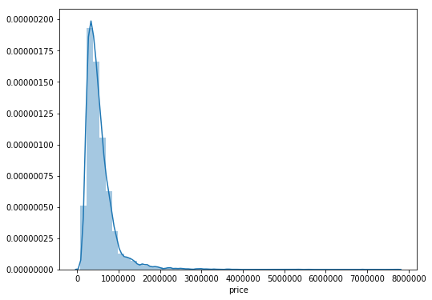

```python
f, ax = plt.subplots(figsize = (8,6))
sns.distplot(train['price'])
print("%s -> Skewness: %f, Kurtosis: %f" %  ('price',train['price'].skew(),
                                                     train['price'].kurt()))
```

- 왜도(Skewness) : 왼쪽으로 치우쳐져 있을수록 값이크고, 오른쪽으로 치우쳐져 있을 수록 값이 작아진다.즉, 0에 가까울수록 좋은 형태
- 첨도(Kurtosis) : 첨도 값이 3에 가까울 경우 정규분포에 가까우며, 첨도 값이 클수록 뾰족하고, 값이 작을 수록 완만해진다.

분석결과

- 전처리 과정에서 왜도와 첨도를 조정해 줄 필요가 있을 것 같다.

```python
#id는 예측하는데 필요 없으므로 삭제
train_id = train['id']
del train['id']
```

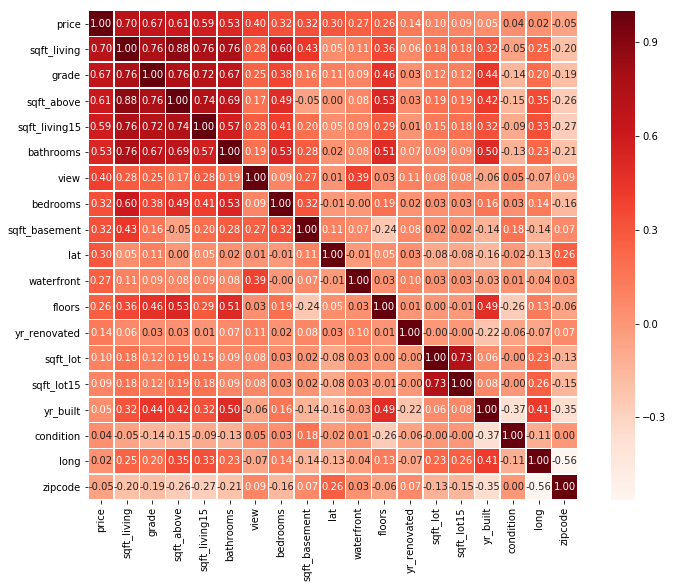

```python
#상관관계 확인
k=20 #히트맵 변수 갯수
corrmat = train.corr() #변수간의 상관관계
cols = corrmat.nlargest(k, 'price')['price'].index #price기준으로 제일 큰순서대로 20개를 뽑아냄
cm = np.corrcoef(train[cols].values.T)
f, ax = plt.subplots(figsize=(12, 9))
sns.heatmap(data = cm, annot=True, square=True, fmt = '.2f', linewidths=.5, cmap='Reds',
            yticklabels = cols.values, xticklabels = cols.values)
```

- sqft_ 열들 즉, 집의 크기가 가격에 제일 영향을 많이 받으며, 집의 등급을 매긴 grade역시 높다.
- 부가적인 방의 갯수, 화장실, 뷰, lat(위도) 까지 0.3 이상으로 보인다.
- date는 String으로 되어있기 때문에 위표에는 없다.

```python
train['date'].describe()
```

```
count               15035
unique                365
top       20140623T000000
freq                  101
Name: date, dtype: object
```

- 유일한 string형태 이며, 뒷부분인 date의 T000000부분은 필요 없어 보여 없애 줄 것이며,
- 년월일단위 까지 사용하는 것보단 년, 월, 일 각각 나눠서 사용
- sqft_living, sqft_above, sqft_living15, sqft_basement, sqft_lot, sqft_lot15 (상관관계높은순)
- sqft는 Square Feet로 평수를 나타내는 것으로 다같이 비교하면서 분석
- sqft_living : 주거 공간의 평방 피트(면적)
- sqft_lot : 부지의 평방 피트(면적)
- sqft_above : 지하실을 제외한 평방 피트(면적)
- sqft_basement : 지하실의 평방 피트(면적)
- sqft_living15 : 2015년 기준 주거 공간의 평방 피트(면적, 집을 재건축했다면, 변화가 있을 수 있음)
- sqft_lot15 : 2015년 기준 부지의 평방 피트(면적, 집을 재건축했다면, 변화가 있을 수 있음)

```
sqft_living -> Skewness: 1.492472, Kurtosis: 5.731178
sqft_living15 -> Skewness: 1.125932, Kurtosis: 1.693097
sqft_lot -> Skewness: 13.350500, Kurtosis: 297.940881
sqft_lot15 -> Skewness: 10.028412, Kurtosis: 174.105395
sqft_above -> Skewness: 1.429070, Kurtosis: 3.380302
sqft_basement -> Skewness: 1.556555, Kurtosis: 2.353893
```

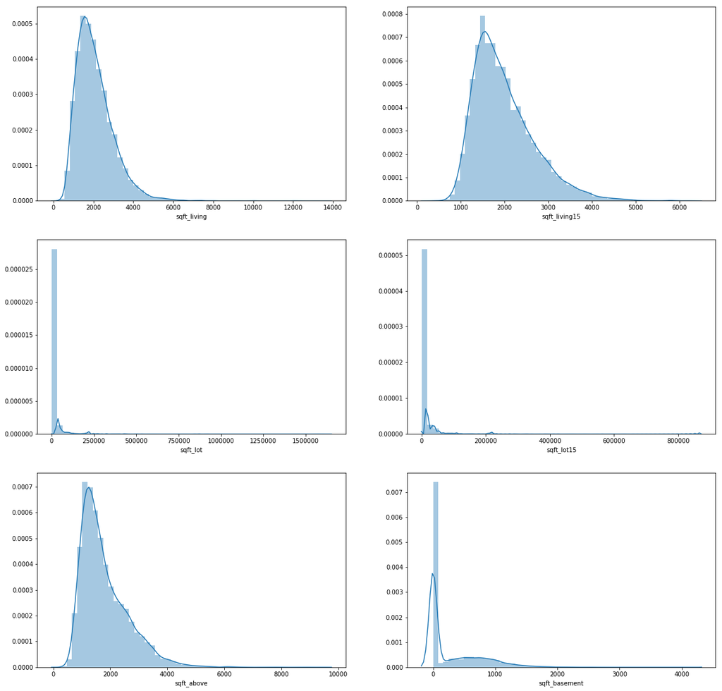

```python
f, ax = plt.subplots(3, 2, figsize = (20,20))

columns = ['sqft_living', 'sqft_living15', 'sqft_lot', 'sqft_lot15','sqft_above','sqft_basement']

count = 0
for row in range(3):
    for col in range(2):
        sns.distplot(train[columns[count]], ax=ax[row][col])
        print("%s -> Skewness: %f, Kurtosis: %f" %  (columns[count],train[columns[count]].skew(),
                                                     train[columns[count]].kurt()))
        count += 1
```

- sqft_living은 15년 이후로 6000이상의 데이터들이 대부분 없어졌다.
- sqft_lot도 15년 이후로 900000이상의 데이터들이 없어졌다.
- sqft_living은 거의 14000이 제일 큰 부분이며, 그에 비해 sqft_lot는 150만 이상의 데이터들 까지 존재
- sqft_above가 10000인것을 보니 sqft_living 10000이상인 부분은 지하실이 차지를 한다고 볼 수 있다.
- sqft_basement는 제일 큰 것이 4000이며, 0의 값이 존재하는 것은 지하실이 없는 곳으로 보면 되겠다.

sqft_living, sqft_living15 분석

- sqft_living은 6000이상의 값들이 대부분 사라져서, 6000이상의 값들만 먼저 확인해보겠다.

```python
train[train['sqft_living']>=6000]
```

|  | date | price | bedrooms | bathrooms | sqft_living | sqft_lot | floors | waterfront | view | condition | grade | sqft_above | sqft_basement | yr_built | yr_renovated | zipcode | lat | long | sqft_living15 | sqft_lot15 |
| --- | --- | --- | --- | --- | --- | --- | --- | --- | --- | --- | --- | --- | --- | --- | --- | --- | --- | --- | --- | --- |
| 300 | 20140710T000000 | 1550000.0 | 5 | 4.25 | 6070 | 171626 | 2.0 | 0 | 0 | 3 | 12 | 6070 | 0 | 1999 | 0 | 98024 | 47.5954 | -121.950 | 4680 | 211267 |
| 385 | 20140618T000000 | 1600000.0 | 6 | 5.00 | 6050 | 230652 | 2.0 | 0 | 3 | 3 | 11 | 6050 | 0 | 2001 | 0 | 98024 | 47.6033 | -121.943 | 4210 | 233971 |
| 425 | 20141211T000000 | 930000.0 | 4 | 4.00 | 6050 | 84942 | 2.5 | 0 | 2 | 3 | 9 | 4150 | 1900 | 2009 | 0 | 98077 | 47.7466 | -122.029 | 2700 | 199504 |
| 799 | 20141110T000000 | 1570000.0 | 5 | 4.50 | 6070 | 14731 | 2.0 | 0 | 0 | 3 | 11 | 6070 | 0 | 2004 | 0 | 98059 | 47.5306 | -122.134 | 4750 | 13404 |
| 842 | 20141020T000000 | 5110800.0 | 5 | 5.25 | 8010 | 45517 | 2.0 | 1 | 4 | 3 | 12 | 5990 | 2020 | 1999 | 0 | 98033 | 47.6767 | -122.211 | 3430 | 26788 |
| 947 | 20150413T000000 | 5300000.0 | 6 | 6.00 | 7390 | 24829 | 2.0 | 1 | 4 | 4 | 12 | 5000 | 2390 | 1991 | 0 | 98040 | 47.5631 | -122.210 | 4320 | 24619 |
| 1045 | 20150413T000000 | 5350000.0 | 5 | 5.00 | 8000 | 23985 | 2.0 | 0 | 4 | 3 | 12 | 6720 | 1280 | 2009 | 0 | 98004 | 47.6232 | -122.220 | 4600 | 21750 |
| 1531 | 20140729T000000 | 1325000.0 | 3 | 3.75 | 6400 | 76665 | 1.0 | 0 | 2 | 4 | 10 | 3810 | 2590 | 1966 | 0 | 98177 | 47.7313 | -122.370 | 3430 | 60548 |
| 1604 | 20140811T000000 | 1760000.0 | 4 | 5.00 | 6055 | 21630 | 1.0 | 0 | 3 | 4 | 12 | 3555 | 2500 | 1996 | 0 | 98006 | 47.5524 | -122.112 | 4890 | 19223 |
| 1882 | 20140815T000000 | 4500000.0 | 5 | 5.50 | 6640 | 40014 | 2.0 | 1 | 4 | 3 | 12 | 6350 | 290 | 2004 | 0 | 98155 | 47.7493 | -122.280 | 3030 | 23408 |
| 1941 | 20140730T000000 | 1110000.0 | 5 | 3.50 | 7350 | 12231 | 2.0 | 0 | 4 | 3 | 11 | 4750 | 2600 | 2001 | 0 | 98065 | 47.5373 | -121.865 | 5380 | 12587 |
| 2160 | 20140929T000000 | 2525000.0 | 4 | 5.50 | 6930 | 45100 | 1.0 | 0 | 0 | 4 | 11 | 4310 | 2620 | 1950 | 1991 | 98006 | 47.5547 | -122.144 | 2560 | 37766 |
| 2228 | 20141117T000000 | 1320000.0 | 4 | 5.25 | 6110 | 10369 | 2.0 | 0 | 0 | 3 | 11 | 6110 | 0 | 2005 | 0 | 98059 | 47.5285 | -122.135 | 4190 | 10762 |
| 2745 | 20140918T000000 | 2950000.0 | 5 | 4.75 | 6240 | 47480 | 1.0 | 0 | 3 | 3 | 11 | 4610 | 1630 | 2003 | 0 | 98040 | 47.5317 | -122.233 | 4170 | 17668 |
| 2775 | 20140611T000000 | 7062500.0 | 5 | 4.50 | 10040 | 37325 | 2.0 | 1 | 2 | 3 | 11 | 7680 | 2360 | 1940 | 2001 | 98004 | 47.6500 | -122.214 | 3930 | 25449 |
| 2859 | 20141007T000000 | 800000.0 | 7 | 6.75 | 7480 | 41664 | 2.0 | 0 | 2 | 3 | 11 | 5080 | 2400 | 1953 | 0 | 98166 | 47.4643 | -122.368 | 2810 | 33190 |
| 3134 | 20140804T000000 | 5570000.0 | 5 | 5.75 | 9200 | 35069 | 2.0 | 0 | 0 | 3 | 13 | 6200 | 3000 | 2001 | 0 | 98039 | 47.6289 | -122.233 | 3560 | 24345 |
| 4036 | 20140624T000000 | 2466350.0 | 5 | 4.75 | 6390 | 13180 | 2.0 | 0 | 0 | 3 | 10 | 4560 | 1830 | 1940 | 0 | 98112 | 47.6312 | -122.291 | 4010 | 8137 |
| 4215 | 20141203T000000 | 2725000.0 | 4 | 4.25 | 6410 | 43838 | 2.5 | 0 | 2 | 4 | 12 | 5610 | 800 | 1906 | 0 | 98144 | 47.5703 | -122.280 | 2270 | 6630 |
| 4266 | 20141120T000000 | 2385000.0 | 4 | 4.00 | 6330 | 13296 | 2.0 | 0 | 2 | 3 | 13 | 4900 | 1430 | 2000 | 0 | 98033 | 47.6488 | -122.201 | 2200 | 9196 |
| 4592 | 20150209T000000 | 1940000.0 | 4 | 5.75 | 7220 | 223462 | 2.0 | 0 | 4 | 3 | 12 | 6220 | 1000 | 2000 | 0 | 98053 | 47.7097 | -122.013 | 2680 | 7593 |
| 4957 | 20140701T000000 | 3800000.0 | 5 | 5.50 | 7050 | 42840 | 1.0 | 0 | 2 | 4 | 13 | 4320 | 2730 | 1978 | 0 | 98004 | 47.6229 | -122.220 | 5070 | 20570 |
| 5108 | 20141013T000000 | 7700000.0 | 6 | 8.00 | 12050 | 27600 | 2.5 | 0 | 3 | 4 | 13 | 8570 | 3480 | 1910 | 1987 | 98102 | 47.6298 | -122.323 | 3940 | 8800 |
| 5560 | 20140923T000000 | 3200000.0 | 6 | 5.00 | 7100 | 18200 | 2.5 | 0 | 0 | 3 | 13 | 5240 | 1860 | 1933 | 2002 | 98199 | 47.6427 | -122.408 | 3130 | 6477 |
| 6469 | 20140919T000000 | 6885000.0 | 6 | 7.75 | 9890 | 31374 | 2.0 | 0 | 4 | 3 | 13 | 8860 | 1030 | 2001 | 0 | 98039 | 47.6305 | -122.240 | 4540 | 42730 |
| 7059 | 20140912T000000 | 1900000.0 | 5 | 4.25 | 6510 | 16471 | 2.0 | 0 | 3 | 4 | 11 | 3250 | 3260 | 1980 | 0 | 98040 | 47.5758 | -122.242 | 4480 | 16471 |
| 7246 | 20141212T000000 | 2983000.0 | 5 | 5.50 | 7400 | 18898 | 2.0 | 0 | 3 | 3 | 13 | 6290 | 1110 | 2001 | 0 | 98006 | 47.5431 | -122.112 | 6110 | 26442 |
| 7644 | 20140828T000000 | 1610000.0 | 5 | 4.50 | 6085 | 142725 | 3.0 | 0 | 0 | 3 | 11 | 6085 | 0 | 2000 | 0 | 98014 | 47.6085 | -121.952 | 4830 | 128457 |
| 7739 | 20140627T000000 | 1820000.0 | 4 | 4.50 | 6640 | 53330 | 2.0 | 0 | 0 | 3 | 12 | 6640 | 0 | 1993 | 0 | 98077 | 47.7283 | -122.046 | 4620 | 68625 |
| 8569 | 20141015T000000 | 1959000.0 | 5 | 4.50 | 6200 | 23373 | 3.0 | 0 | 1 | 4 | 11 | 5050 | 1150 | 1988 | 0 | 98040 | 47.5632 | -122.215 | 3700 | 14486 |
| 8912 | 20140505T000000 | 2280000.0 | 7 | 8.00 | 13540 | 307752 | 3.0 | 0 | 4 | 3 | 12 | 9410 | 4130 | 1999 | 0 | 98053 | 47.6675 | -121.986 | 4850 | 217800 |
| 8977 | 20140529T000000 | 3100000.0 | 6 | 4.25 | 6980 | 15682 | 3.0 | 0 | 4 | 4 | 12 | 5330 | 1650 | 1999 | 0 | 98040 | 47.5552 | -122.231 | 3930 | 18367 |
| 9814 | 20140904T000000 | 3300000.0 | 5 | 4.75 | 6200 | 13873 | 2.0 | 1 | 4 | 4 | 11 | 4440 | 1760 | 1989 | 0 | 98008 | 47.6050 | -122.112 | 2940 | 13525 |
| 10152 | 20140611T000000 | 2888000.0 | 5 | 6.25 | 8670 | 64033 | 2.0 | 0 | 4 | 3 | 13 | 6120 | 2550 | 1965 | 2003 | 98177 | 47.7295 | -122.372 | 4140 | 81021 |
| 10869 | 20140815T000000 | 1825000.0 | 3 | 3.75 | 6030 | 39317 | 2.0 | 0 | 0 | 3 | 11 | 4440 | 1590 | 1991 | 0 | 98004 | 47.6055 | -122.210 | 4040 | 12333 |
| 12436 | 20140708T000000 | 2458000.0 | 4 | 5.25 | 6500 | 14986 | 2.0 | 0 | 0 | 3 | 11 | 5180 | 1320 | 2001 | 0 | 98039 | 47.6304 | -122.236 | 2270 | 8119 |
| 12845 | 20141020T000000 | 3300000.0 | 8 | 4.00 | 7710 | 11750 | 3.5 | 0 | 0 | 5 | 12 | 6090 | 1620 | 1904 | 0 | 98112 | 47.6263 | -122.314 | 4210 | 8325 |
| 12921 | 20140708T000000 | 1135250.0 | 5 | 4.00 | 7320 | 217800 | 2.0 | 0 | 0 | 3 | 11 | 7320 | 0 | 1992 | 0 | 98058 | 47.4473 | -122.086 | 3270 | 34500 |
| 13355 | 20140516T000000 | 2000000.0 | 5 | 4.25 | 6490 | 10862 | 2.0 | 0 | 3 | 4 | 11 | 3940 | 2550 | 1991 | 0 | 98040 | 47.5728 | -122.205 | 3290 | 14080 |
| 13809 | 20150122T000000 | 2700000.0 | 4 | 4.00 | 7850 | 89651 | 2.0 | 0 | 0 | 3 | 12 | 7850 | 0 | 2006 | 0 | 98027 | 47.5406 | -121.982 | 6210 | 95832 |
| 14216 | 20150507T000000 | 2998000.0 | 5 | 4.00 | 6670 | 16481 | 2.0 | 0 | 0 | 3 | 12 | 4960 | 1710 | 2007 | 0 | 98004 | 47.6409 | -122.221 | 4800 | 16607 |
| 14225 | 20150415T000000 | 1600000.0 | 4 | 5.50 | 6530 | 871200 | 2.0 | 0 | 2 | 3 | 11 | 6530 | 0 | 2008 | 0 | 98014 | 47.6640 | -121.878 | 1280 | 858132 |
| 14237 | 20150123T000000 | 1800000.0 | 4 | 3.50 | 6370 | 205603 | 2.0 | 0 | 0 | 3 | 12 | 6370 | 0 | 2008 | 0 | 98027 | 47.5016 | -121.905 | 1490 | 33580 |
| 14475 | 20140828T000000 | 1275000.0 | 6 | 5.25 | 6160 | 27490 | 2.0 | 0 | 0 | 3 | 11 | 4040 | 2120 | 2007 | 0 | 98074 | 47.6094 | -122.023 | 4225 | 9100 |

- 대충보니 비슷한 크기로 sqft_living이 줄어든것 같습니다. 상관관계를 산점도로 확인해보겠다.

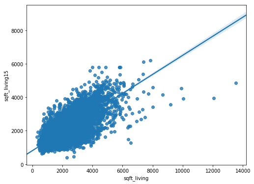

```python
f, ax = plt.subplots(figsize=(8,6))
sns.regplot(x='sqft_living', y='sqft_living15', data=train[['sqft_living','sqft_living15']])
```

- 변수간의 양의 상관관계를 가지고 있다.
- 변수간의 상관관계가 높을 시 모델링에 문제를 줄 수 있으므로 다시 생각해 볼 필요가 있다.

```python
# sqft_living15에 비해 상당히 주거공간이 큰경우는 대저택일 것같다.
# 이런 대저택들이 대부분의 주택들의 가격을 대변할 수 있을까...?
train[(train['sqft_living']>10000) ]
```

|  | date | price | bedrooms | bathrooms | sqft_living | sqft_lot | floors | waterfront | view | condition | grade | sqft_above | sqft_basement | yr_built | yr_renovated | zipcode | lat | long | sqft_living15 | sqft_lot15 |
| --- | --- | --- | --- | --- | --- | --- | --- | --- | --- | --- | --- | --- | --- | --- | --- | --- | --- | --- | --- | --- |
| 2775 | 20140611T000000 | 7062500.0 | 5 | 4.5 | 10040 | 37325 | 2.0 | 1 | 2 | 3 | 11 | 7680 | 2360 | 1940 | 2001 | 98004 | 47.6500 | -122.214 | 3930 | 25449 |
| 5108 | 20141013T000000 | 7700000.0 | 6 | 8.0 | 12050 | 27600 | 2.5 | 0 | 3 | 4 | 13 | 8570 | 3480 | 1910 | 1987 | 98102 | 47.6298 | -122.323 | 3940 | 8800 |
| 8912 | 20140505T000000 | 2280000.0 | 7 | 8.0 | 13540 | 307752 | 3.0 | 0 | 4 | 3 | 12 | 9410 | 4130 | 1999 | 0 | 98053 | 47.6675 | -121.986 | 4850 | 217800 |

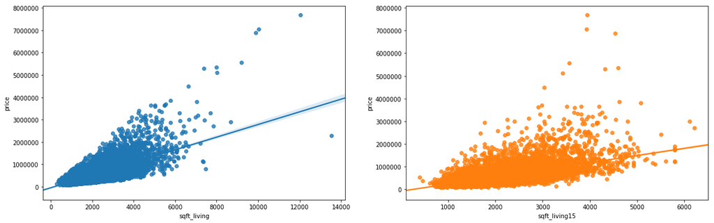

```python
f, ax = plt.subplots(1, 2, figsize=(20,6))
sns.regplot(x='sqft_living', y='price', data=train[['sqft_living','price']], ax=ax[0])
sns.regplot(x='sqft_living15', y='price', data=train[['sqft_living15','price']], ax=ax[1])
```

- 집의 크기가 클 수록 가격은 엄청 뛰는 반면에 생각 보다 엄청 작은 값이 존재 한다 확인해 볼 필요가 있다.

```python
train[train['sqft_living']>7500].sort_values('sqft_living', ascending = False)
```

|  | date | price | bedrooms | bathrooms | sqft_living | sqft_lot | floors | waterfront | view | condition | grade | sqft_above | sqft_basement | yr_built | yr_renovated | zipcode | lat | long | sqft_living15 | sqft_lot15 |
| --- | --- | --- | --- | --- | --- | --- | --- | --- | --- | --- | --- | --- | --- | --- | --- | --- | --- | --- | --- | --- |
| 8912 | 20140505T000000 | 2280000.0 | 7 | 8.00 | 13540 | 307752 | 3.0 | 0 | 4 | 3 | 12 | 9410 | 4130 | 1999 | 0 | 98053 | 47.6675 | -121.986 | 4850 | 217800 |
| 5108 | 20141013T000000 | 7700000.0 | 6 | 8.00 | 12050 | 27600 | 2.5 | 0 | 3 | 4 | 13 | 8570 | 3480 | 1910 | 1987 | 98102 | 47.6298 | -122.323 | 3940 | 8800 |
| 2775 | 20140611T000000 | 7062500.0 | 5 | 4.50 | 10040 | 37325 | 2.0 | 1 | 2 | 3 | 11 | 7680 | 2360 | 1940 | 2001 | 98004 | 47.6500 | -122.214 | 3930 | 25449 |
| 6469 | 20140919T000000 | 6885000.0 | 6 | 7.75 | 9890 | 31374 | 2.0 | 0 | 4 | 3 | 13 | 8860 | 1030 | 2001 | 0 | 98039 | 47.6305 | -122.240 | 4540 | 42730 |
| 3134 | 20140804T000000 | 5570000.0 | 5 | 5.75 | 9200 | 35069 | 2.0 | 0 | 0 | 3 | 13 | 6200 | 3000 | 2001 | 0 | 98039 | 47.6289 | -122.233 | 3560 | 24345 |
| 10152 | 20140611T000000 | 2888000.0 | 5 | 6.25 | 8670 | 64033 | 2.0 | 0 | 4 | 3 | 13 | 6120 | 2550 | 1965 | 2003 | 98177 | 47.7295 | -122.372 | 4140 | 81021 |
| 842 | 20141020T000000 | 5110800.0 | 5 | 5.25 | 8010 | 45517 | 2.0 | 1 | 4 | 3 | 12 | 5990 | 2020 | 1999 | 0 | 98033 | 47.6767 | -122.211 | 3430 | 26788 |
| 1045 | 20150413T000000 | 5350000.0 | 5 | 5.00 | 8000 | 23985 | 2.0 | 0 | 4 | 3 | 12 | 6720 | 1280 | 2009 | 0 | 98004 | 47.6232 | -122.220 | 4600 | 21750 |
| 13809 | 20150122T000000 | 2700000.0 | 4 | 4.00 | 7850 | 89651 | 2.0 | 0 | 0 | 3 | 12 | 7850 | 0 | 2006 | 0 | 98027 | 47.5406 | -121.982 | 6210 | 95832 |
| 12845 | 20141020T000000 | 3300000.0 | 8 | 4.00 | 7710 | 11750 | 3.5 | 0 | 0 | 5 | 12 | 6090 | 1620 | 1904 | 0 | 98112 | 47.6263 | -122.314 | 4210 | 8325 |

- 모든 면에서 우수한데에 비해 집 가격이 너무 낮다.
- long에서의 차이가 보이고, 지역적 특성을 확인해 볼 필요가 있다. 지금은 이상치로 생각하자.

sqft_lot, lot15분석

- 먼저, sqft_lot15가 900000이상으로 데이터가 사라졌으므로 sqft_lot의 900000이상의 데이터를 확인

```python
train[train['sqft_lot']>=900000]
```

|  | date | price | bedrooms | bathrooms | sqft_living | sqft_lot | floors | waterfront | view | condition | grade | sqft_above | sqft_basement | yr_built | yr_renovated | zipcode | lat | long | sqft_living15 | sqft_lot15 |
| --- | --- | --- | --- | --- | --- | --- | --- | --- | --- | --- | --- | --- | --- | --- | --- | --- | --- | --- | --- | --- |
| 1231 | 20150327T000000 | 700000.0 | 4 | 1.00 | 1300 | 1651359 | 1.0 | 0 | 3 | 4 | 6 | 1300 | 0 | 1920 | 0 | 98022 | 47.2313 | -122.023 | 2560 | 425581 |
| 2803 | 20140905T000000 | 998000.0 | 4 | 3.25 | 3770 | 982998 | 2.0 | 0 | 0 | 3 | 10 | 3770 | 0 | 1992 | 0 | 98058 | 47.4140 | -122.087 | 2290 | 37141 |
| 4719 | 20150320T000000 | 1998000.0 | 2 | 2.50 | 3900 | 920423 | 2.0 | 0 | 0 | 3 | 12 | 3900 | 0 | 2009 | 0 | 98065 | 47.5371 | -121.756 | 2720 | 411962 |
| 5392 | 20140521T000000 | 542500.0 | 5 | 3.25 | 3010 | 1074218 | 1.5 | 0 | 0 | 5 | 8 | 2010 | 1000 | 1931 | 0 | 98027 | 47.4564 | -122.004 | 2450 | 68825 |
| 5468 | 20150119T000000 | 855000.0 | 4 | 3.50 | 4030 | 1024068 | 2.0 | 0 | 0 | 3 | 10 | 4030 | 0 | 2006 | 0 | 98045 | 47.4619 | -121.744 | 1830 | 11700 |

sqft_lot의 크기가 100배 에서 2배까지 들쑥날쑥하게 크기가 줄어든다.  
그러나 상관관계는 높다고 나오니 확인해 볼 필요가 있다.

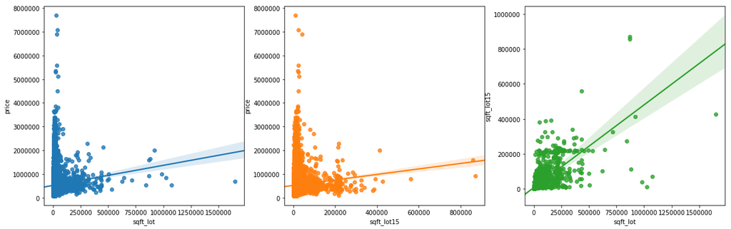

```python
f, ax = plt.subplots(1, 3, figsize=(20,6))
sns.regplot(x='sqft_lot', y='price', data=train[['sqft_lot','price']], ax=ax[0])
sns.regplot(x='sqft_lot15', y='price', data=train[['sqft_lot15','price']], ax=ax[1])
sns.regplot(x='sqft_lot', y='sqft_lot15', data=train[['sqft_lot','sqft_lot15']], ax=ax[2])
```

- 산점도를 보니 부지크기가 줄어들었지만 전체적인 형태는 비슷하다.
- 부지가 큰것에 비해 작은 경우에 가격이 엄청 큰값이 밀집되어있다.
- 다른 feature들을 보며 이유를 알아볼 필요가 있다.
- 선형식의 오차는 상당히 큰것으로 보인다.
- sqft_lot와 sqft_lot15는 둘다 변수를 삭제할지, 아니면 변수의 높은 값들을 삭제를 할지,
- 변수간의 상관관계를 낮추는 방향으로 가야할지 분석해볼 필요가 있다.

```python
train[train['price']>4000000].sort_values(['sqft_lot','sqft_lot15'])
```

|  | date | price | bedrooms | bathrooms | sqft_living | sqft_lot | floors | waterfront | view | condition | grade | sqft_above | sqft_basement | yr_built | yr_renovated | zipcode | lat | long | sqft_living15 | sqft_lot15 |
| --- | --- | --- | --- | --- | --- | --- | --- | --- | --- | --- | --- | --- | --- | --- | --- | --- | --- | --- | --- | --- |
| 1045 | 20150413T000000 | 5350000.0 | 5 | 5.00 | 8000 | 23985 | 2.0 | 0 | 4 | 3 | 12 | 6720 | 1280 | 2009 | 0 | 98004 | 47.6232 | -122.220 | 4600 | 21750 |
| 947 | 20150413T000000 | 5300000.0 | 6 | 6.00 | 7390 | 24829 | 2.0 | 1 | 4 | 4 | 12 | 5000 | 2390 | 1991 | 0 | 98040 | 47.5631 | -122.210 | 4320 | 24619 |
| 5108 | 20141013T000000 | 7700000.0 | 6 | 8.00 | 12050 | 27600 | 2.5 | 0 | 3 | 4 | 13 | 8570 | 3480 | 1910 | 1987 | 98102 | 47.6298 | -122.323 | 3940 | 8800 |
| 6469 | 20140919T000000 | 6885000.0 | 6 | 7.75 | 9890 | 31374 | 2.0 | 0 | 4 | 3 | 13 | 8860 | 1030 | 2001 | 0 | 98039 | 47.6305 | -122.240 | 4540 | 42730 |
| 3134 | 20140804T000000 | 5570000.0 | 5 | 5.75 | 9200 | 35069 | 2.0 | 0 | 0 | 3 | 13 | 6200 | 3000 | 2001 | 0 | 98039 | 47.6289 | -122.233 | 3560 | 24345 |
| 2775 | 20140611T000000 | 7062500.0 | 5 | 4.50 | 10040 | 37325 | 2.0 | 1 | 2 | 3 | 11 | 7680 | 2360 | 1940 | 2001 | 98004 | 47.6500 | -122.214 | 3930 | 25449 |
| 1882 | 20140815T000000 | 4500000.0 | 5 | 5.50 | 6640 | 40014 | 2.0 | 1 | 4 | 3 | 12 | 6350 | 290 | 2004 | 0 | 98155 | 47.7493 | -122.280 | 3030 | 23408 |
| 842 | 20141020T000000 | 5110800.0 | 5 | 5.25 | 8010 | 45517 | 2.0 | 1 | 4 | 3 | 12 | 5990 | 2020 | 1999 | 0 | 98033 | 47.6767 | -122.211 | 3430 | 26788 |

- 부지가 2만에서 4만대로 다른것에 비해 작지만 그외의 상관관계가 높은 feature에 대해서는 큰 문제가 없어보인다.

sqft_above, sqft_basement분석

```python
len(train[train['sqft_living']!=(train['sqft_above']+train['sqft_basement'])])
```

```
0
```

- above와 basement는 basement가 sqft_living - basement = above라고 볼 수 있다.
- 잘 못 계산 된것도 없는 것을 볼 수 있다.
- 그렇지만 이런 경우에 basement가 존재하지 않는 경우도 많을 것이며 price에 상관관계가 높다면 영향을 끼칠 수 있다.

```python
base_zero = len(train[train['sqft_basement']==0])
base_zero_not = len(train[train['sqft_basement']!=0])
total_base = len(train['sqft_basement'])

basement_count = pd.Series([base_zero, base_zero_not])
basement_pnt = basement_count/total_base*100
basement = pd.concat([basement_count, basement_pnt], axis=1, keys = ['Count', '%'])
basement.index = ['0의값', '0을 제외한 값']
basement
```

|  | Count | % |
| --- | --- | --- |
| 0의값 | 9143 | 60.81144 |
| 0을 제외한 값 | 5892 | 39.18856 |

- sqft_basement가 없는 경우가 60%이상이므로 그대로 데이터를 사용하기엔 부적절해 보인다.
- 데이터를 지하실의 유무로 0과 1로 바꿔주는 것이 좋을 것 같다.
- 바꾸기 전에 데이터의 이상유무도 확인해보자.

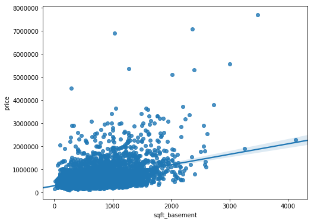

```python
f, ax = plt.subplots(figsize=(8,6))
sns.regplot(x='sqft_basement', y='price', data=train[train['sqft_basement']!=0][['sqft_basement','price']])
```

```python
train[train['price']>4000000]
```

|  | date | price | bedrooms | bathrooms | sqft_living | sqft_lot | floors | waterfront | view | condition | grade | sqft_above | sqft_basement | yr_built | yr_renovated | zipcode | lat | long | sqft_living15 | sqft_lot15 |
| --- | --- | --- | --- | --- | --- | --- | --- | --- | --- | --- | --- | --- | --- | --- | --- | --- | --- | --- | --- | --- |
| 842 | 20141020T000000 | 5110800.0 | 5 | 5.25 | 8010 | 45517 | 2.0 | 1 | 4 | 3 | 12 | 5990 | 2020 | 1999 | 0 | 98033 | 47.6767 | -122.211 | 3430 | 26788 |
| 947 | 20150413T000000 | 5300000.0 | 6 | 6.00 | 7390 | 24829 | 2.0 | 1 | 4 | 4 | 12 | 5000 | 2390 | 1991 | 0 | 98040 | 47.5631 | -122.210 | 4320 | 24619 |
| 1045 | 20150413T000000 | 5350000.0 | 5 | 5.00 | 8000 | 23985 | 2.0 | 0 | 4 | 3 | 12 | 6720 | 1280 | 2009 | 0 | 98004 | 47.6232 | -122.220 | 4600 | 21750 |
| 1882 | 20140815T000000 | 4500000.0 | 5 | 5.50 | 6640 | 40014 | 2.0 | 1 | 4 | 3 | 12 | 6350 | 290 | 2004 | 0 | 98155 | 47.7493 | -122.280 | 3030 | 23408 |
| 2775 | 20140611T000000 | 7062500.0 | 5 | 4.50 | 10040 | 37325 | 2.0 | 1 | 2 | 3 | 11 | 7680 | 2360 | 1940 | 2001 | 98004 | 47.6500 | -122.214 | 3930 | 25449 |
| 3134 | 20140804T000000 | 5570000.0 | 5 | 5.75 | 9200 | 35069 | 2.0 | 0 | 0 | 3 | 13 | 6200 | 3000 | 2001 | 0 | 98039 | 47.6289 | -122.233 | 3560 | 24345 |
| 5108 | 20141013T000000 | 7700000.0 | 6 | 8.00 | 12050 | 27600 | 2.5 | 0 | 3 | 4 | 13 | 8570 | 3480 | 1910 | 1987 | 98102 | 47.6298 | -122.323 | 3940 | 8800 |
| 6469 | 20140919T000000 | 6885000.0 | 6 | 7.75 | 9890 | 31374 | 2.0 | 0 | 4 | 3 | 13 | 8860 | 1030 | 2001 | 0 | 98039 | 47.6305 | -122.240 | 4540 | 42730 |

- basement가 작은 데에 비해 가격이 큰 이유에 대해 큰 이상한 점을 찾지 못하였다.

분석결과

- sqft_lot는 큰 상관관계가 없어보이며, 변수를 삭제할지 아니면 lot와 lot15간의 상관관계를 줄이는 방향으로 갈지  
  생각해봐야한다.
- sqft_living에서 13000의 값에서 이상치가 보입니다. 지금은 삭제하는 방향으로 가며, 후에 long을 분석하여  
  재 검토해야 한다.
- sqft_living과 sqft_living15간의 상관관계가 높게 나왔기 때문에 상관관계를 줄여주는 방향도 생각해볼 필요가  
  있다.
- sqft_above와 sqft_living과의 상관관계도 높게 나온 부분에 대해 생각해 볼 필요가 있다.
- sqft_basement는 지하실이 없는 경우가 60%가 넘기때문에 지하실이 있고 없고의 유무로 바꾼 후 판단해야 된다.

grade

- 1~3 : 최소 건축 기준에 미치지 못함. 보통 오두막 또는 열등한 구조
- 4 : 일반적으로 오래 되거나, 품질이 낮은 건축물
- 5 : 낮은 건축비용과 솜씨. 작고 심플한 디자인
- 6 : 평균에서 바로 밑, 품질이 낮은 재료와 심플한 디자인
- 7 : 평균
- 8 : 평균 이상의 건축물과 디자인, 보통 외관과 내관의 마무리 작업에서 좋은 재료 사용
- 9 : 추가로 내부 외부 디자인과 품질이 더 좋은 건축 디자인
- 10 : 이 품질의 주택은 일반적으로 높은 품질의 특징을 가지고 있음.마감작업이 더 좋고 설계품질이 바닥 평면에 표시 됨. 평방 피트가 크다
- 11 : 사용자가 디자인하고 높은 품질의 마감작업과추가로 단단한 목재 시설, 욕실 비품 및 고급스러운 옵션을 제공
- 12 : 사용자가 디자인하고 훌륭한 건축가들. 모든 재료들은 아주 높은 품질이고 모든 편의 시설 존재
- 13 : 일반적으로 사용자가 디자인과 설계. 저택 수준. 다량의 고품질 캐비닛, 목재장식, 대리석, 진입 방법 등
- 참고 - Discussion (More information about housing grades)

주로 디자인을 보며, 내 외부, 사용자가 디자인, 방크기, 고급스러움, 옵션식으로 grade를 매기는 것 같다.

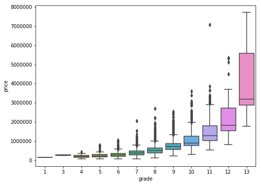

```python
data = pd.concat([train['price'], train['grade']], axis = 1)
f, ax = plt.subplots(figsize = (8,6))
fig = sns.boxplot(x='grade', y='price', data=data)
```

- 3에서 소수의 값이 이상한 점이 보인다.
- 11에서 차이가 큰 이상치가 나타난다.
- 13에서 값들이 갑자기 엄청 커진다.

```python
train[(train['grade'] == 11) & (train['price']>3000000)]
```

|  | date | price | bedrooms | bathrooms | sqft_living | sqft_lot | floors | waterfront | view | condition | grade | sqft_above | sqft_basement | yr_built | yr_renovated | zipcode | lat | long | sqft_living15 | sqft_lot15 |
| --- | --- | --- | --- | --- | --- | --- | --- | --- | --- | --- | --- | --- | --- | --- | --- | --- | --- | --- | --- | --- |
| 1499 | 20141114T000000 | 3850000.0 | 4 | 4.25 | 5770 | 21300 | 2.0 | 1 | 4 | 4 | 11 | 5770 | 0 | 1980 | 0 | 98040 | 47.5850 | -122.222 | 4620 | 22748 |
| 2775 | 20140611T000000 | 7062500.0 | 5 | 4.50 | 10040 | 37325 | 2.0 | 1 | 2 | 3 | 11 | 7680 | 2360 | 1940 | 2001 | 98004 | 47.6500 | -122.214 | 3930 | 25449 |
| 4598 | 20150421T000000 | 3650000.0 | 6 | 4.75 | 5480 | 19401 | 1.5 | 1 | 4 | 5 | 11 | 3910 | 1570 | 1936 | 0 | 98105 | 47.6515 | -122.277 | 3510 | 15810 |
| 5156 | 20140825T000000 | 3100000.0 | 3 | 3.00 | 3920 | 13085 | 2.0 | 1 | 4 | 4 | 11 | 3920 | 0 | 1996 | 0 | 98040 | 47.5716 | -122.204 | 3450 | 13287 |
| 7297 | 20150508T000000 | 3400000.0 | 4 | 4.00 | 4260 | 11765 | 2.0 | 0 | 0 | 3 | 11 | 3280 | 980 | 1939 | 2010 | 98112 | 47.6380 | -122.288 | 4260 | 10408 |
| 8047 | 20150109T000000 | 3200000.0 | 3 | 3.25 | 4560 | 13363 | 1.0 | 0 | 4 | 3 | 11 | 2760 | 1800 | 1995 | 0 | 98004 | 47.6205 | -122.214 | 4060 | 13362 |
| 9814 | 20140904T000000 | 3300000.0 | 5 | 4.75 | 6200 | 13873 | 2.0 | 1 | 4 | 4 | 11 | 4440 | 1760 | 1989 | 0 | 98008 | 47.6050 | -122.112 | 2940 | 13525 |
| 10645 | 20140911T000000 | 3640900.0 | 4 | 3.25 | 4830 | 22257 | 2.0 | 1 | 4 | 4 | 11 | 4830 | 0 | 1990 | 0 | 98039 | 47.6409 | -122.241 | 3820 | 25582 |
| 10648 | 20150212T000000 | 3065000.0 | 5 | 3.00 | 4150 | 7500 | 2.5 | 0 | 4 | 5 | 11 | 3510 | 640 | 1909 | 0 | 98119 | 47.6303 | -122.362 | 2250 | 4050 |
| 12646 | 20141230T000000 | 3300000.0 | 3 | 3.25 | 4220 | 41300 | 1.0 | 1 | 4 | 4 | 11 | 2460 | 1760 | 1958 | 1987 | 98008 | 47.6083 | -122.110 | 3810 | 30401 |
| 14116 | 20140826T000000 | 3204000.0 | 4 | 4.00 | 4810 | 18851 | 2.0 | 0 | 3 | 3 | 11 | 4810 | 0 | 2007 | 0 | 98004 | 47.6364 | -122.214 | 3970 | 19929 |
| 14231 | 20150402T000000 | 3345000.0 | 5 | 3.75 | 5350 | 15360 | 1.0 | 0 | 1 | 3 | 11 | 3040 | 2310 | 2008 | 0 | 98004 | 47.6480 | -122.218 | 3740 | 15940 |

- grade가 11, price가 700만이 넘는 데이터와 그바로 다음 데이터를 비교해보면, sqft_living값이 상당히 큰 것으로 알 수 있다. 가격이 sqft_living의 영향을 받고, 그외의 옵션에서 크기에 비해 grade가 낮게 평가 된 것 같다.

```python
train[(train['price']>7000000)].sort_values('grade')
```

|  | date | price | bedrooms | bathrooms | sqft_living | sqft_lot | floors | waterfront | view | condition | grade | sqft_above | sqft_basement | yr_built | yr_renovated | zipcode | lat | long | sqft_living15 | sqft_lot15 |
| --- | --- | --- | --- | --- | --- | --- | --- | --- | --- | --- | --- | --- | --- | --- | --- | --- | --- | --- | --- | --- |
| 2775 | 20140611T000000 | 7062500.0 | 5 | 4.5 | 10040 | 37325 | 2.0 | 1 | 2 | 3 | 11 | 7680 | 2360 | 1940 | 2001 | 98004 | 47.6500 | -122.214 | 3930 | 25449 |
| 5108 | 20141013T000000 | 7700000.0 | 6 | 8.0 | 12050 | 27600 | 2.5 | 0 | 3 | 4 | 13 | 8570 | 3480 | 1910 | 1987 | 98102 | 47.6298 | -122.323 | 3940 | 8800 |

- sqft_living이 700만이 넘는 데이터와 비교하였을 때 sqft_living의 크기가 비슷한 것을 알 수 있다.
- 따라서 이상치라고 제거하기엔 어려워 보인다.

```python
train[(train['grade']== 13)].sort_values('price')
```

|  | date | price | bedrooms | bathrooms | sqft_living | sqft_lot | floors | waterfront | view | condition | grade | sqft_above | sqft_basement | yr_built | yr_renovated | zipcode | lat | long | sqft_living15 | sqft_lot15 |
| --- | --- | --- | --- | --- | --- | --- | --- | --- | --- | --- | --- | --- | --- | --- | --- | --- | --- | --- | --- | --- |
| 3867 | 20141010T000000 | 1780000.0 | 4 | 3.25 | 4890 | 13402 | 2.0 | 0 | 0 | 3 | 13 | 4890 | 0 | 2004 | 0 | 98059 | 47.5303 | -122.131 | 5790 | 13539 |
| 4266 | 20141120T000000 | 2385000.0 | 4 | 4.00 | 6330 | 13296 | 2.0 | 0 | 2 | 3 | 13 | 4900 | 1430 | 2000 | 0 | 98033 | 47.6488 | -122.201 | 2200 | 9196 |
| 10152 | 20140611T000000 | 2888000.0 | 5 | 6.25 | 8670 | 64033 | 2.0 | 0 | 4 | 3 | 13 | 6120 | 2550 | 1965 | 2003 | 98177 | 47.7295 | -122.372 | 4140 | 81021 |
| 7246 | 20141212T000000 | 2983000.0 | 5 | 5.50 | 7400 | 18898 | 2.0 | 0 | 3 | 3 | 13 | 6290 | 1110 | 2001 | 0 | 98006 | 47.5431 | -122.112 | 6110 | 26442 |
| 5560 | 20140923T000000 | 3200000.0 | 6 | 5.00 | 7100 | 18200 | 2.5 | 0 | 0 | 3 | 13 | 5240 | 1860 | 1933 | 2002 | 98199 | 47.6427 | -122.408 | 3130 | 6477 |
| 4957 | 20140701T000000 | 3800000.0 | 5 | 5.50 | 7050 | 42840 | 1.0 | 0 | 2 | 4 | 13 | 4320 | 2730 | 1978 | 0 | 98004 | 47.6229 | -122.220 | 5070 | 20570 |
| 3134 | 20140804T000000 | 5570000.0 | 5 | 5.75 | 9200 | 35069 | 2.0 | 0 | 0 | 3 | 13 | 6200 | 3000 | 2001 | 0 | 98039 | 47.6289 | -122.233 | 3560 | 24345 |
| 6469 | 20140919T000000 | 6885000.0 | 6 | 7.75 | 9890 | 31374 | 2.0 | 0 | 4 | 3 | 13 | 8860 | 1030 | 2001 | 0 | 98039 | 47.6305 | -122.240 | 4540 | 42730 |
| 5108 | 20141013T000000 | 7700000.0 | 6 | 8.00 | 12050 | 27600 | 2.5 | 0 | 3 | 4 | 13 | 8570 | 3480 | 1910 | 1987 | 98102 | 47.6298 | -122.323 | 3940 | 8800 |

- sqft_living이 클 수록 기하급수적으로 가격이 커짐에 따라 grade 13에서는 전체적으로 값이 큰 구간으로 나왔다.

분석결과

- grade가 3인 데이터가 갯수가 적기 때문에 편향이 일어날수도 있으므로 제거하겠다.

bathrooms, bedrooms

bathrooms 분석

- full bath (1) : 화장실, 세면대, 샤워실, 욕조
- 3/4 bath (0.75) : 화장실, 세면대, 샤워실
- half bath (0.5) : 화장실, 세면대  
  하지만 수치에 따라 화장실, 세면대, 샤워실, 욕조의 갯수는 정확히 알 수 없을 것 같다.

참고 - Discussion (bathrooms값에 소수점의 의미)

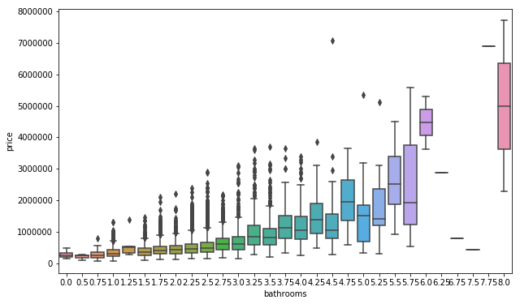

```python
f, ax = plt.subplots(figsize = (10,6))
sns.boxplot(x='bathrooms', y='price', data=train[['bathrooms', 'price']])
```

- 4.5에서 큰 이상치가 보임
- 6.25, 6.75, 7.5에서 낮은 값이 하나만 존재함.

```python
train[(train['bathrooms'] == 4.5) & (train['price']>7000000)]
```

|  | date | price | bedrooms | bathrooms | sqft_living | sqft_lot | floors | waterfront | view | condition | grade | sqft_above | sqft_basement | yr_built | yr_renovated | zipcode | lat | long | sqft_living15 | sqft_lot15 |
| --- | --- | --- | --- | --- | --- | --- | --- | --- | --- | --- | --- | --- | --- | --- | --- | --- | --- | --- | --- | --- |
| 2775 | 20140611T000000 | 7062500.0 | 5 | 4.5 | 10040 | 37325 | 2.0 | 1 | 2 | 3 | 11 | 7680 | 2360 | 1940 | 2001 | 98004 | 47.65 | -122.214 | 3930 | 25449 |

- 4.5 이상치는 좀 전의 grade가 11인 경우와 같은 경우인 것 같다.

```python
train[(train['bathrooms']>=6.25) & (train['bathrooms']<=7.5)].sort_values('bathrooms')
```

|  | date | price | bedrooms | bathrooms | sqft_living | sqft_lot | floors | waterfront | view | condition | grade | sqft_above | sqft_basement | yr_built | yr_renovated | zipcode | lat | long | sqft_living15 | sqft_lot15 |
| --- | --- | --- | --- | --- | --- | --- | --- | --- | --- | --- | --- | --- | --- | --- | --- | --- | --- | --- | --- | --- |
| 10152 | 20140611T000000 | 2888000.0 | 5 | 6.25 | 8670 | 64033 | 2.0 | 0 | 4 | 3 | 13 | 6120 | 2550 | 1965 | 2003 | 98177 | 47.7295 | -122.372 | 4140 | 81021 |
| 2859 | 20141007T000000 | 800000.0 | 7 | 6.75 | 7480 | 41664 | 2.0 | 0 | 2 | 3 | 11 | 5080 | 2400 | 1953 | 0 | 98166 | 47.4643 | -122.368 | 2810 | 33190 |
| 5990 | 20140811T000000 | 450000.0 | 9 | 7.50 | 4050 | 6504 | 2.0 | 0 | 0 | 3 | 7 | 4050 | 0 | 1996 | 0 | 98144 | 47.5923 | -122.301 | 1448 | 3866 |

- bathrooms 6.25인 경우는 grade가 13이고, sqft_living도 8670이다. 이와 비슷한 값들을 비교해보고 price가 어떤지 확인해봐야 할 것 같다.
- bathrooms 6.75인 경우도 grade가 11로 높은 편이며, sqft_living도 7480으로 높은 편이다.
- bathrooms 7.50은 grade가 7로 보통의 수준과, sqft_living는 4050입니다. 유사한 값들과 비교하여 판단해야될 것 같다.

```python
train[(train['grade'] == 13) & (train['price']>= 2000000)].sort_values('price')
```

|  | date | price | bedrooms | bathrooms | sqft_living | sqft_lot | floors | waterfront | view | condition | grade | sqft_above | sqft_basement | yr_built | yr_renovated | zipcode | lat | long | sqft_living15 | sqft_lot15 |
| --- | --- | --- | --- | --- | --- | --- | --- | --- | --- | --- | --- | --- | --- | --- | --- | --- | --- | --- | --- | --- |
| 4266 | 20141120T000000 | 2385000.0 | 4 | 4.00 | 6330 | 13296 | 2.0 | 0 | 2 | 3 | 13 | 4900 | 1430 | 2000 | 0 | 98033 | 47.6488 | -122.201 | 2200 | 9196 |
| 10152 | 20140611T000000 | 2888000.0 | 5 | 6.25 | 8670 | 64033 | 2.0 | 0 | 4 | 3 | 13 | 6120 | 2550 | 1965 | 2003 | 98177 | 47.7295 | -122.372 | 4140 | 81021 |
| 7246 | 20141212T000000 | 2983000.0 | 5 | 5.50 | 7400 | 18898 | 2.0 | 0 | 3 | 3 | 13 | 6290 | 1110 | 2001 | 0 | 98006 | 47.5431 | -122.112 | 6110 | 26442 |
| 5560 | 20140923T000000 | 3200000.0 | 6 | 5.00 | 7100 | 18200 | 2.5 | 0 | 0 | 3 | 13 | 5240 | 1860 | 1933 | 2002 | 98199 | 47.6427 | -122.408 | 3130 | 6477 |
| 4957 | 20140701T000000 | 3800000.0 | 5 | 5.50 | 7050 | 42840 | 1.0 | 0 | 2 | 4 | 13 | 4320 | 2730 | 1978 | 0 | 98004 | 47.6229 | -122.220 | 5070 | 20570 |
| 3134 | 20140804T000000 | 5570000.0 | 5 | 5.75 | 9200 | 35069 | 2.0 | 0 | 0 | 3 | 13 | 6200 | 3000 | 2001 | 0 | 98039 | 47.6289 | -122.233 | 3560 | 24345 |
| 6469 | 20140919T000000 | 6885000.0 | 6 | 7.75 | 9890 | 31374 | 2.0 | 0 | 4 | 3 | 13 | 8860 | 1030 | 2001 | 0 | 98039 | 47.6305 | -122.240 | 4540 | 42730 |
| 5108 | 20141013T000000 | 7700000.0 | 6 | 8.00 | 12050 | 27600 | 2.5 | 0 | 3 | 4 | 13 | 8570 | 3480 | 1910 | 1987 | 98102 | 47.6298 | -122.323 | 3940 | 8800 |

- 이 구간에서는 sqft_living에 따라 값의 차이가 엄청 커져 이상하게 보이는 것 같다. bathrooms 6.25인 경우는 이상하다고 보기 힘들 것 같다.

```python
train[(train['sqft_living']>=7000) & (train['grade'] >= 11)].sort_values('price')
```

|  | date | price | bedrooms | bathrooms | sqft_living | sqft_lot | floors | waterfront | view | condition | grade | sqft_above | sqft_basement | yr_built | yr_renovated | zipcode | lat | long | sqft_living15 | sqft_lot15 |
| --- | --- | --- | --- | --- | --- | --- | --- | --- | --- | --- | --- | --- | --- | --- | --- | --- | --- | --- | --- | --- |
| 2859 | 20141007T000000 | 800000.0 | 7 | 6.75 | 7480 | 41664 | 2.0 | 0 | 2 | 3 | 11 | 5080 | 2400 | 1953 | 0 | 98166 | 47.4643 | -122.368 | 2810 | 33190 |
| 1941 | 20140730T000000 | 1110000.0 | 5 | 3.50 | 7350 | 12231 | 2.0 | 0 | 4 | 3 | 11 | 4750 | 2600 | 2001 | 0 | 98065 | 47.5373 | -121.865 | 5380 | 12587 |
| 12921 | 20140708T000000 | 1135250.0 | 5 | 4.00 | 7320 | 217800 | 2.0 | 0 | 0 | 3 | 11 | 7320 | 0 | 1992 | 0 | 98058 | 47.4473 | -122.086 | 3270 | 34500 |
| 4592 | 20150209T000000 | 1940000.0 | 4 | 5.75 | 7220 | 223462 | 2.0 | 0 | 4 | 3 | 12 | 6220 | 1000 | 2000 | 0 | 98053 | 47.7097 | -122.013 | 2680 | 7593 |
| 8912 | 20140505T000000 | 2280000.0 | 7 | 8.00 | 13540 | 307752 | 3.0 | 0 | 4 | 3 | 12 | 9410 | 4130 | 1999 | 0 | 98053 | 47.6675 | -121.986 | 4850 | 217800 |
| 13809 | 20150122T000000 | 2700000.0 | 4 | 4.00 | 7850 | 89651 | 2.0 | 0 | 0 | 3 | 12 | 7850 | 0 | 2006 | 0 | 98027 | 47.5406 | -121.982 | 6210 | 95832 |
| 10152 | 20140611T000000 | 2888000.0 | 5 | 6.25 | 8670 | 64033 | 2.0 | 0 | 4 | 3 | 13 | 6120 | 2550 | 1965 | 2003 | 98177 | 47.7295 | -122.372 | 4140 | 81021 |
| 7246 | 20141212T000000 | 2983000.0 | 5 | 5.50 | 7400 | 18898 | 2.0 | 0 | 3 | 3 | 13 | 6290 | 1110 | 2001 | 0 | 98006 | 47.5431 | -122.112 | 6110 | 26442 |
| 5560 | 20140923T000000 | 3200000.0 | 6 | 5.00 | 7100 | 18200 | 2.5 | 0 | 0 | 3 | 13 | 5240 | 1860 | 1933 | 2002 | 98199 | 47.6427 | -122.408 | 3130 | 6477 |
| 12845 | 20141020T000000 | 3300000.0 | 8 | 4.00 | 7710 | 11750 | 3.5 | 0 | 0 | 5 | 12 | 6090 | 1620 | 1904 | 0 | 98112 | 47.6263 | -122.314 | 4210 | 8325 |
| 4957 | 20140701T000000 | 3800000.0 | 5 | 5.50 | 7050 | 42840 | 1.0 | 0 | 2 | 4 | 13 | 4320 | 2730 | 1978 | 0 | 98004 | 47.6229 | -122.220 | 5070 | 20570 |
| 842 | 20141020T000000 | 5110800.0 | 5 | 5.25 | 8010 | 45517 | 2.0 | 1 | 4 | 3 | 12 | 5990 | 2020 | 1999 | 0 | 98033 | 47.6767 | -122.211 | 3430 | 26788 |
| 947 | 20150413T000000 | 5300000.0 | 6 | 6.00 | 7390 | 24829 | 2.0 | 1 | 4 | 4 | 12 | 5000 | 2390 | 1991 | 0 | 98040 | 47.5631 | -122.210 | 4320 | 24619 |
| 1045 | 20150413T000000 | 5350000.0 | 5 | 5.00 | 8000 | 23985 | 2.0 | 0 | 4 | 3 | 12 | 6720 | 1280 | 2009 | 0 | 98004 | 47.6232 | -122.220 | 4600 | 21750 |
| 3134 | 20140804T000000 | 5570000.0 | 5 | 5.75 | 9200 | 35069 | 2.0 | 0 | 0 | 3 | 13 | 6200 | 3000 | 2001 | 0 | 98039 | 47.6289 | -122.233 | 3560 | 24345 |
| 6469 | 20140919T000000 | 6885000.0 | 6 | 7.75 | 9890 | 31374 | 2.0 | 0 | 4 | 3 | 13 | 8860 | 1030 | 2001 | 0 | 98039 | 47.6305 | -122.240 | 4540 | 42730 |
| 2775 | 20140611T000000 | 7062500.0 | 5 | 4.50 | 10040 | 37325 | 2.0 | 1 | 2 | 3 | 11 | 7680 | 2360 | 1940 | 2001 | 98004 | 47.6500 | -122.214 | 3930 | 25449 |
| 5108 | 20141013T000000 | 7700000.0 | 6 | 8.00 | 12050 | 27600 | 2.5 | 0 | 3 | 4 | 13 | 8570 | 3480 | 1910 | 1987 | 98102 | 47.6298 | -122.323 | 3940 | 8800 |

- bathrooms가 6.75 인 경우는 sqft_living15를 제외한 가격이 작을 이유 가 없다. 이상치로 판단

```python
train[(train['sqft_living']>=3500) & (train['grade'] == 7)].sort_values('price')
```

|  | date | price | bedrooms | bathrooms | sqft_living | sqft_lot | floors | waterfront | view | condition | grade | sqft_above | sqft_basement | yr_built | yr_renovated | zipcode | lat | long | sqft_living15 | sqft_lot15 |
| --- | --- | --- | --- | --- | --- | --- | --- | --- | --- | --- | --- | --- | --- | --- | --- | --- | --- | --- | --- | --- |
| 1188 | 20150105T000000 | 330000.0 | 4 | 2.50 | 3504 | 6000 | 2.0 | 0 | 0 | 3 | 7 | 3504 | 0 | 2006 | 0 | 98001 | 47.3012 | -122.285 | 2790 | 5231 |
| 1990 | 20150123T000000 | 340000.0 | 4 | 2.75 | 3527 | 7200 | 2.0 | 0 | 0 | 3 | 7 | 3527 | 0 | 2005 | 0 | 98198 | 47.3823 | -122.300 | 2490 | 7200 |
| 6370 | 20140917T000000 | 350000.0 | 6 | 4.50 | 3500 | 8504 | 2.0 | 0 | 0 | 3 | 7 | 3500 | 0 | 1980 | 0 | 98155 | 47.7351 | -122.295 | 1550 | 8460 |
| 286 | 20140825T000000 | 360000.0 | 4 | 1.75 | 3730 | 16980 | 1.0 | 0 | 0 | 4 | 7 | 2150 | 1580 | 1974 | 0 | 98022 | 47.1775 | -122.022 | 1880 | 16963 |
| 10159 | 20150312T000000 | 380000.0 | 5 | 3.25 | 3800 | 15500 | 1.0 | 0 | 0 | 3 | 7 | 2490 | 1310 | 1965 | 0 | 98032 | 47.3862 | -122.280 | 2000 | 13980 |
| 9148 | 20140910T000000 | 419000.0 | 7 | 3.25 | 4340 | 8521 | 2.0 | 0 | 0 | 3 | 7 | 2550 | 1790 | 1986 | 0 | 98106 | 47.5200 | -122.338 | 1890 | 8951 |
| 5990 | 20140811T000000 | 450000.0 | 9 | 7.50 | 4050 | 6504 | 2.0 | 0 | 0 | 3 | 7 | 4050 | 0 | 1996 | 0 | 98144 | 47.5923 | -122.301 | 1448 | 3866 |
| 4048 | 20140813T000000 | 487500.0 | 5 | 3.50 | 3530 | 218472 | 2.0 | 0 | 0 | 3 | 7 | 2380 | 1150 | 1999 | 0 | 98019 | 47.7309 | -121.905 | 2110 | 211404 |
| 6662 | 20141002T000000 | 490000.0 | 4 | 4.25 | 4480 | 5715 | 2.0 | 0 | 0 | 3 | 7 | 3680 | 800 | 2003 | 0 | 98030 | 47.3730 | -122.179 | 2190 | 6070 |
| 10958 | 20140630T000000 | 500000.0 | 4 | 3.00 | 3720 | 15048 | 3.0 | 0 | 0 | 3 | 7 | 3720 | 0 | 1979 | 2014 | 98059 | 47.5116 | -122.144 | 2020 | 15180 |
| 5778 | 20141113T000000 | 506000.0 | 5 | 3.75 | 3880 | 8370 | 2.0 | 0 | 0 | 4 | 7 | 3880 | 0 | 2004 | 0 | 98056 | 47.4811 | -122.179 | 2160 | 4651 |
| 3228 | 20140929T000000 | 550000.0 | 3 | 2.00 | 3650 | 843309 | 2.0 | 0 | 0 | 4 | 7 | 3650 | 0 | 1991 | 0 | 98070 | 47.3627 | -122.496 | 1870 | 273992 |
| 13407 | 20141125T000000 | 575000.0 | 8 | 3.00 | 3840 | 15990 | 1.0 | 0 | 0 | 3 | 7 | 2530 | 1310 | 1961 | 0 | 98034 | 47.7111 | -122.211 | 1380 | 8172 |
| 12463 | 20140717T000000 | 580000.0 | 5 | 2.75 | 3550 | 9600 | 2.0 | 0 | 0 | 3 | 7 | 3550 | 0 | 1960 | 0 | 98033 | 47.6766 | -122.186 | 3370 | 9600 |
| 8780 | 20140717T000000 | 587000.0 | 5 | 3.50 | 3610 | 52595 | 2.0 | 0 | 0 | 4 | 7 | 3610 | 0 | 1989 | 0 | 98014 | 47.6832 | -121.907 | 1620 | 60112 |
| 8527 | 20140929T000000 | 599000.0 | 4 | 4.75 | 3700 | 11000 | 1.0 | 0 | 0 | 4 | 7 | 1840 | 1860 | 1962 | 0 | 98028 | 47.7680 | -122.251 | 1720 | 11564 |
| 2912 | 20140507T000000 | 599999.0 | 9 | 4.50 | 3830 | 6988 | 2.5 | 0 | 0 | 3 | 7 | 2450 | 1380 | 1938 | 0 | 98103 | 47.6927 | -122.338 | 1460 | 6291 |
| 5097 | 20140728T000000 | 627000.0 | 5 | 3.25 | 3570 | 5425 | 2.0 | 0 | 0 | 3 | 7 | 3570 | 0 | 2005 | 0 | 98075 | 47.5933 | -122.007 | 2690 | 5347 |
| 2041 | 20140721T000000 | 635000.0 | 6 | 2.50 | 3880 | 5700 | 2.0 | 0 | 0 | 3 | 7 | 3880 | 0 | 2003 | 0 | 98053 | 47.6816 | -122.038 | 2620 | 5070 |
| 3270 | 20141118T000000 | 643500.0 | 6 | 5.25 | 3600 | 3960 | 2.0 | 0 | 0 | 3 | 7 | 2400 | 1200 | 1971 | 0 | 98126 | 47.5656 | -122.372 | 1450 | 4600 |
| 10575 | 20141029T000000 | 650000.0 | 10 | 2.00 | 3610 | 11914 | 2.0 | 0 | 0 | 4 | 7 | 3010 | 600 | 1958 | 0 | 98006 | 47.5705 | -122.175 | 2040 | 11914 |
| 1698 | 20140611T000000 | 665000.0 | 6 | 3.00 | 4250 | 4400 | 2.5 | 0 | 0 | 4 | 7 | 3020 | 1230 | 1902 | 0 | 98118 | 47.5584 | -122.283 | 1520 | 4950 |
| 3193 | 20140829T000000 | 673200.0 | 5 | 3.00 | 4180 | 8561 | 2.0 | 0 | 0 | 3 | 7 | 4180 | 0 | 2003 | 0 | 98053 | 47.6833 | -122.040 | 3425 | 6591 |
| 3010 | 20150106T000000 | 700000.0 | 9 | 3.00 | 3680 | 4400 | 2.0 | 0 | 0 | 3 | 7 | 2830 | 850 | 1908 | 0 | 98102 | 47.6374 | -122.324 | 1960 | 2450 |
| 8937 | 20141208T000000 | 760000.0 | 5 | 2.00 | 3920 | 5250 | 1.5 | 0 | 0 | 5 | 7 | 2560 | 1360 | 1910 | 0 | 98144 | 47.5798 | -122.294 | 1830 | 4240 |
| 9395 | 20140728T000000 | 920000.0 | 3 | 2.25 | 3650 | 5353 | 2.0 | 0 | 4 | 4 | 7 | 2200 | 1450 | 1947 | 0 | 98144 | 47.5949 | -122.291 | 1950 | 4970 |
| 12112 | 20141029T000000 | 979700.0 | 5 | 3.00 | 3730 | 5500 | 1.5 | 0 | 0 | 3 | 7 | 2160 | 1570 | 1927 | 0 | 98102 | 47.6507 | -122.320 | 1890 | 5500 |
| 10633 | 20140929T000000 | 1031000.0 | 3 | 2.50 | 4110 | 35741 | 2.0 | 0 | 0 | 3 | 7 | 4110 | 0 | 1976 | 0 | 98033 | 47.6642 | -122.171 | 2710 | 8865 |
| 9950 | 20141113T000000 | 1100000.0 | 5 | 2.25 | 4320 | 7620 | 2.0 | 0 | 0 | 3 | 7 | 2880 | 1440 | 1973 | 2014 | 98115 | 47.6824 | -122.287 | 1880 | 7620 |
| 12346 | 20150115T000000 | 2050000.0 | 4 | 3.25 | 3580 | 19989 | 1.5 | 1 | 4 | 4 | 7 | 3480 | 100 | 1915 | 1965 | 98125 | 47.7087 | -122.276 | 2410 | 6389 |

- 이 경우도 가격이 엄청 작을 이유가 크게 없으므로, 이상치로 판단

bedrooms 분석

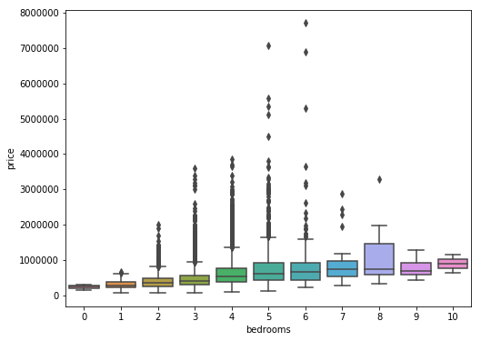

```python
f, ax = plt.subplots(figsize = (8,6))
sns.boxplot(x='bedrooms', y='price', data=train[['bedrooms', 'price']])
```

- 5와 6의 이상치들을 확인해보겠다. 아마 bathrooms와 같은 상황일 것 같다.
- 방의 경우 median 값을 중심으로 살펴보면 어느정도 선형관계를 띄는것을 볼 수 있다. 그리고 방의 갯수가 2~6의 경우 방이 적음에도 값이 큰 값들이 많다. 이는 우리나라의 경우처럼 방의 크기는 작아도 강남처럼 비싼 지역일 가능성이 높다.

```python
train[((train['bedrooms']==5) | (train['bedrooms'] == 6)) & (train['price']>=4000000)]
```

|  | date | price | bedrooms | bathrooms | sqft_living | sqft_lot | floors | waterfront | view | condition | grade | sqft_above | sqft_basement | yr_built | yr_renovated | zipcode | lat | long | sqft_living15 | sqft_lot15 |
| --- | --- | --- | --- | --- | --- | --- | --- | --- | --- | --- | --- | --- | --- | --- | --- | --- | --- | --- | --- | --- |
| 842 | 20141020T000000 | 5110800.0 | 5 | 5.25 | 8010 | 45517 | 2.0 | 1 | 4 | 3 | 12 | 5990 | 2020 | 1999 | 0 | 98033 | 47.6767 | -122.211 | 3430 | 26788 |
| 947 | 20150413T000000 | 5300000.0 | 6 | 6.00 | 7390 | 24829 | 2.0 | 1 | 4 | 4 | 12 | 5000 | 2390 | 1991 | 0 | 98040 | 47.5631 | -122.210 | 4320 | 24619 |
| 1045 | 20150413T000000 | 5350000.0 | 5 | 5.00 | 8000 | 23985 | 2.0 | 0 | 4 | 3 | 12 | 6720 | 1280 | 2009 | 0 | 98004 | 47.6232 | -122.220 | 4600 | 21750 |
| 1882 | 20140815T000000 | 4500000.0 | 5 | 5.50 | 6640 | 40014 | 2.0 | 1 | 4 | 3 | 12 | 6350 | 290 | 2004 | 0 | 98155 | 47.7493 | -122.280 | 3030 | 23408 |
| 2775 | 20140611T000000 | 7062500.0 | 5 | 4.50 | 10040 | 37325 | 2.0 | 1 | 2 | 3 | 11 | 7680 | 2360 | 1940 | 2001 | 98004 | 47.6500 | -122.214 | 3930 | 25449 |
| 3134 | 20140804T000000 | 5570000.0 | 5 | 5.75 | 9200 | 35069 | 2.0 | 0 | 0 | 3 | 13 | 6200 | 3000 | 2001 | 0 | 98039 | 47.6289 | -122.233 | 3560 | 24345 |
| 5108 | 20141013T000000 | 7700000.0 | 6 | 8.00 | 12050 | 27600 | 2.5 | 0 | 3 | 4 | 13 | 8570 | 3480 | 1910 | 1987 | 98102 | 47.6298 | -122.323 | 3940 | 8800 |
| 6469 | 20140919T000000 | 6885000.0 | 6 | 7.75 | 9890 | 31374 | 2.0 | 0 | 4 | 3 | 13 | 8860 | 1030 | 2001 | 0 | 98039 | 47.6305 | -122.240 | 4540 | 42730 |

분석결과

- bathrooms 6.75와 7.5 데이터를 제거

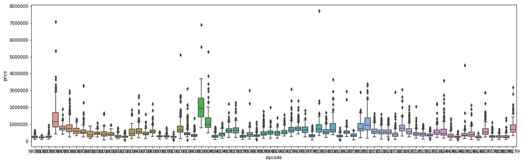

```python
# zipcode
f, ax = plt.subplots(figsize=(20,6))
sns.boxplot(x = train['zipcode'], y= train['price'])
```

- zipcode에 따라 가격이 엄청 큰 데이터들도 있는 것 같다.
- 가격이 큰 경우와 작은 경우로 해서 값의 순위를 주는 방향으로 수정
1. Data Preprocessing (Feature Engineering)

```python
# 이상치 제거
train = train.drop((train[train['sqft_living']>13000]).index, axis=0)
train = train.drop((train[train['grade']== 3]).index, axis=0)
train = train.drop((train[(train['bathrooms']== 6.75)]).index, axis=0)
train = train.drop((train[(train['bathrooms']== 7.5)]).index, axis=0)
```

```python
# 변수 수정
train_test_data = [train, test]
```

```python
for dataset in train_test_data:
    #date -> 년, 월, 일 단위로 새로운 칼럼 만듦
    dataset['year'] = dataset['date'].str[:4]
    dataset['year'] = dataset['year'].astype(int)
    dataset['month'] = dataset['date'].str[4:6]
    dataset['month'] = dataset['month'].astype(int)
    dataset['day'] = dataset['date'].str[6:8]
    dataset['day'] = dataset['day'].astype(int)

    # 부지 면적 대비 실제 사용 면적 비율
    dataset['sqft_ratio'] = dataset['sqft_living'] / dataset['sqft_lot']

    # 15개의 부지 면적 대비 실제 사용 면적 평균 비율
    dataset['sqft_ratio15'] = dataset['sqft_living15'] / dataset['sqft_lot15']

    #지하실 유무
    dataset['is_basement'] = dataset['sqft_basement'].map(lambda x: 1 if x != 0 else 0)

    #재건축 여부
    dataset['is_renovated'] = dataset['yr_renovated'].apply(lambda x: 0 if x == 0 else 1)

    #재건축 년도 수정
    dataset['yr_renovated'] = dataset['yr_renovated'].apply(lambda x: np.nan if x == 0 else x)
    dataset['yr_renovated'] = dataset['yr_renovated'].fillna(dataset['yr_built'])

    #구매했을 때 집의 년식 (리모델링한경우는 리모델링 한 날 부터)
    dataset['age'] = dataset['year']-dataset['yr_renovated']

    #구매당시 집을 지었는지 여부
    dataset['new_built'] = dataset['year']-dataset['yr_built']
    dataset['new_built'] = dataset['new_built'].apply(lambda x : 1 if x==0 else 0)

    #year는 데이터가 두개라서 0과 1로 바꿔줌
    dataset['year'] = dataset['year'].apply(lambda x : 0 if x == 2014 else 1)
```

```python
#zipcode 수정
train_zipcode = train[['zipcode','price']].groupby('zipcode', as_index = False).mean().sort_values('price')
train_zipcode.head()
```

|  | zipcode | price |
| --- | --- | --- |
| 1 | 98002 | 235664.526718 |
| 64 | 98168 | 236837.172973 |
| 20 | 98032 | 255418.411765 |
| 0 | 98001 | 272469.577406 |
| 13 | 98023 | 282004.647564 |

```python
zipcode_num = {}
for i in range(0, 70):
    zipcode = train_zipcode['zipcode'].iloc[i]
    zipcode_num[zipcode] = i

zipcode_num
```

```
{98002: 0,
 98168: 1,
 98032: 2,
 98001: 3,
 98023: 4,
 98148: 5,
 98003: 6,
 98188: 7,
 98031: 8,
 98030: 9,
 98198: 10,
 98055: 11,
 98178: 12,
 98042: 13,
 98106: 14,
```

[output cut: 55 more lines]

```python
train_test_data = [train, test]
```

```python
for dataset in train_test_data:
    dataset['zipcode_num'] = dataset['zipcode'].map(zipcode_num)
```

```python
train.head()
```

|  | date | price | bedrooms | bathrooms | sqft_living | sqft_lot | floors | waterfront | view | condition | ... | year | month | day | sqft_ratio | sqft_ratio15 | is_basement | is_renovated | age | new_built | zipcode_num |
| --- | --- | --- | --- | --- | --- | --- | --- | --- | --- | --- | --- | --- | --- | --- | --- | --- | --- | --- | --- | --- | --- |
| 0 | 20141013T000000 | 221900.0 | 3 | 1.00 | 1180 | 5650 | 1.0 | 0 | 0 | 3 | ... | 0 | 10 | 13 | 0.208850 | 0.237168 | 0 | 0 | 59.0 | 0 | 12 |
| 1 | 20150225T000000 | 180000.0 | 2 | 1.00 | 770 | 10000 | 1.0 | 0 | 0 | 3 | ... | 1 | 2 | 25 | 0.077000 | 0.337385 | 0 | 0 | 82.0 | 0 | 30 |
| 2 | 20150218T000000 | 510000.0 | 3 | 2.00 | 1680 | 8080 | 1.0 | 0 | 0 | 3 | ... | 1 | 2 | 18 | 0.207921 | 0.239904 | 0 | 0 | 28.0 | 0 | 56 |
| 3 | 20140627T000000 | 257500.0 | 3 | 2.25 | 1715 | 6819 | 2.0 | 0 | 0 | 3 | ... | 0 | 6 | 27 | 0.251503 | 0.328201 | 0 | 0 | 19.0 | 0 | 6 |
| 4 | 20150115T000000 | 291850.0 | 3 | 1.50 | 1060 | 9711 | 1.0 | 0 | 0 | 3 | ... | 1 | 1 | 15 | 0.109155 | 0.169910 | 0 | 0 | 52.0 | 0 | 10 |

5 rows × 30 columns

```python
#above는 삭제 시 성능 더 좋아짐
drop_columns = ['date', 'sqft_above']
train = train.drop(drop_columns, axis = 1)
test = test.drop(drop_columns, axis = 1)
train.head()
```

|  | price | bedrooms | bathrooms | sqft_living | sqft_lot | floors | waterfront | view | condition | grade | ... | year | month | day | sqft_ratio | sqft_ratio15 | is_basement | is_renovated | age | new_built | zipcode_num |
| --- | --- | --- | --- | --- | --- | --- | --- | --- | --- | --- | --- | --- | --- | --- | --- | --- | --- | --- | --- | --- | --- |
| 0 | 221900.0 | 3 | 1.00 | 1180 | 5650 | 1.0 | 0 | 0 | 3 | 7 | ... | 0 | 10 | 13 | 0.208850 | 0.237168 | 0 | 0 | 59.0 | 0 | 12 |
| 1 | 180000.0 | 2 | 1.00 | 770 | 10000 | 1.0 | 0 | 0 | 3 | 6 | ... | 1 | 2 | 25 | 0.077000 | 0.337385 | 0 | 0 | 82.0 | 0 | 30 |
| 2 | 510000.0 | 3 | 2.00 | 1680 | 8080 | 1.0 | 0 | 0 | 3 | 8 | ... | 1 | 2 | 18 | 0.207921 | 0.239904 | 0 | 0 | 28.0 | 0 | 56 |
| 3 | 257500.0 | 3 | 2.25 | 1715 | 6819 | 2.0 | 0 | 0 | 3 | 7 | ... | 0 | 6 | 27 | 0.251503 | 0.328201 | 0 | 0 | 19.0 | 0 | 6 |
| 4 | 291850.0 | 3 | 1.50 | 1060 | 9711 | 1.0 | 0 | 0 | 3 | 7 | ... | 1 | 1 | 15 | 0.109155 | 0.169910 | 0 | 0 | 52.0 | 0 | 10 |

5 rows × 28 columns

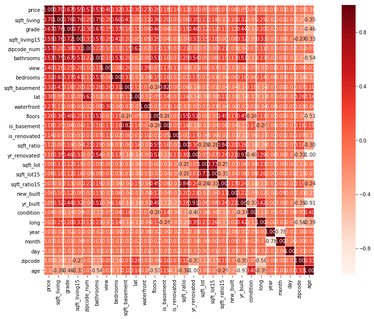

```python
#상관관계 확인
k=30 #히트맵 변수 갯수
corrmat = train.corr()
cols = corrmat.nlargest(k, 'price')['price'].index
cm = np.corrcoef(train[cols].values.T)
f, ax = plt.subplots(figsize=(20, 10))
sns.heatmap(data = cm, annot=True, square=True, fmt = '.2f', linewidths=.5, cmap='Reds',
            yticklabels = cols.values, xticklabels = cols.values)
```

```python
# 왜도 조정
train_columns = []
for column in train.columns:
    if train[column].skew() >= 1:
        print("%s -> Skewness: %f, Kurtosis: %f" %  (column,train[column].skew(),
                                                 train[column].kurt()))
        train_columns.append(column)
    elif train[column].kurt() >= 3:
        print("%s -> Skewness: %f, Kurtosis: %f" %  (column,train[column].skew(),
                                                 train[column].kurt()))
        train_columns.append(column)
```

```
price -> Skewness: 4.293549, Kurtosis: 40.247978
sqft_living -> Skewness: 1.381974, Kurtosis: 4.259952
sqft_lot -> Skewness: 13.391767, Kurtosis: 299.632175
waterfront -> Skewness: 11.726121, Kurtosis: 135.519938
view -> Skewness: 3.380768, Kurtosis: 10.777865
condition -> Skewness: 1.044606, Kurtosis: 0.556178
sqft_basement -> Skewness: 1.522502, Kurtosis: 2.004472
sqft_living15 -> Skewness: 1.124135, Kurtosis: 1.686036
sqft_lot15 -> Skewness: 10.057013, Kurtosis: 175.180160
sqft_ratio -> Skewness: 2.465630, Kurtosis: 12.536339
sqft_ratio15 -> Skewness: 2.155503, Kurtosis: 6.378417
is_renovated -> Skewness: 4.568076, Kurtosis: 18.869833
new_built -> Skewness: 6.644282, Kurtosis: 42.152092
```

```python
# 정규분포모형을 가질 수 있도록 첨도와 왜도를 조정
# 조정하는 방법에는 square root, quarter root, log 등이 있다.
# log에서 0의 값이 들어왔을 때 무한으로 가는 것을 방지하도록 1 더해주는 log1p를 사용

# columns = ['sqft_living', 'sqft_living15', 'sqft_lot', 'sqft_lot15', 'sqft_above']

train['price'] = np.log1p(train['price'])
print("%s -> Skewness: %f, Kurtosis: %f" % ('price', train['price'].skew(), train['price'].kurt()))

for column in train_columns[1:]:
    train[column] = np.log1p(train[column])
    test[column] = np.log1p(test[column])
    print("%s -> Skewness: %f, Kurtosis: %f" %  (column,train[column].skew(),
                                                 train[column].kurt()))
```

```
price -> Skewness: 0.432187, Kurtosis: 0.730937
sqft_living -> Skewness: -0.042787, Kurtosis: -0.090506
sqft_lot -> Skewness: 0.988462, Kurtosis: 3.353772
waterfront -> Skewness: 11.726121, Kurtosis: 135.519938
view -> Skewness: 2.962102, Kurtosis: 7.284356
condition -> Skewness: 0.619232, Kurtosis: 1.169328
sqft_basement -> Skewness: 0.488318, Kurtosis: -1.707946
sqft_living15 -> Skewness: 0.210022, Kurtosis: -0.200001
sqft_lot15 -> Skewness: 0.988663, Kurtosis: 3.583904
sqft_ratio -> Skewness: 1.427940, Kurtosis: 2.799723
sqft_ratio15 -> Skewness: 1.455232, Kurtosis: 2.876422
is_renovated -> Skewness: 4.568076, Kurtosis: 18.869833
new_built -> Skewness: 6.644282, Kurtosis: 42.152092
```

1. Modeling

```python
#단순선형회귀모형

from sklearn.linear_model import LinearRegression
import statsmodels.api as sm

train_columns = [c for c in train.columns if c not in ['price']]

model = sm.OLS(train['price'], train[train_columns])
result = model.fit()
print(result.summary())
```

```
                            OLS Regression Results
==============================================================================
Dep. Variable:                  price   R-squared:                       0.860
Model:                            OLS   Adj. R-squared:                  0.860
Method:                 Least Squares   F-statistic:                     3556.
Date:                Fri, 11 Oct 2019   Prob (F-statistic):               0.00
Time:                        15:58:44   Log-Likelihood:                 3087.7
No. Observations:               15030   AIC:                            -6121.
Df Residuals:                   15003   BIC:                            -5916.
Df Model:                          26
Covariance Type:            nonrobust
=================================================================================
                    coef    std err          t      P>|t|      [0.025      0.975]
---------------------------------------------------------------------------------
bedrooms         -0.0187      0.002     -7.602      0.000      -0.023      -0.014
bathrooms         0.0563      0.004     14.532      0.000       0.049       0.064
sqft_living       0.3776      0.011     34.545      0.000       0.356       0.399
sqft_lot          0.0932      0.007     13.373      0.000       0.080       0.107
floors            0.0099      0.005      1.916      0.055      -0.000       0.020
waterfront        0.5720      0.030     19.338      0.000       0.514       0.630
view              0.1400      0.005     27.173      0.000       0.130       0.150
condition         0.2107      0.013     16.204      0.000       0.185       0.236
grade             0.1080      0.003     42.988      0.000       0.103       0.113
sqft_basement    -0.0353      0.005     -7.311      0.000      -0.045      -0.026
yr_built         -0.0016      0.000     -4.892      0.000      -0.002      -0.001
yr_renovated     -0.0217      0.002    -12.016      0.000      -0.025      -0.018
zipcode          -0.0002   3.95e-05     -4.240      0.000      -0.000   -9.01e-05
lat               0.4417      0.016     27.162      0.000       0.410       0.474
long             -0.4066      0.016    -25.170      0.000      -0.438      -0.375
sqft_living15     0.1019      0.011      9.342      0.000       0.080       0.123
sqft_lot15       -0.0531      0.008     -6.439      0.000      -0.069      -0.037
year              0.0855      0.006     14.574      0.000       0.074       0.097
month             0.0019      0.001      2.310      0.021       0.000       0.004
day              -0.0003      0.000     -1.655      0.098      -0.001    5.71e-05
sqft_ratio        0.2492      0.034      7.273      0.000       0.182       0.316
sqft_ratio15     -0.0861      0.039     -2.228      0.026      -0.162      -0.010
is_basement       0.1940      0.030      6.436      0.000       0.135       0.253
is_renovated      0.1180      0.029      4.046      0.000       0.061       0.175
age              -0.0212      0.002    -11.802      0.000      -0.025      -0.018
new_built         0.1818      0.017     10.806      0.000       0.149       0.215
zipcode_num       0.0118      0.000     90.399      0.000       0.012       0.012
==============================================================================
Omnibus:                      566.005   Durbin-Watson:                   2.010
Prob(Omnibus):                  0.000   Jarque-Bera (JB):             1673.938
Skew:                          -0.083   Prob(JB):                         0.00
Kurtosis:                       4.626   Cond. No.                     3.01e+06
==============================================================================

Warnings:
[1] Standard Errors assume that the covariance matrix of the errors is correctly specified.
[2] The condition number is large, 3.01e+06. This might indicate that there are
strong multicollinearity or other numerical problems.
```

```python
from sklearn.linear_model import ElasticNet, Lasso
from sklearn.ensemble import GradientBoostingRegressor, RandomForestRegressor
from sklearn.kernel_ridge import KernelRidge
from sklearn.pipeline import make_pipeline
from sklearn.preprocessing import RobustScaler
from sklearn.model_selection import KFold, cross_val_score, train_test_split
from sklearn.metrics import mean_squared_error
import xgboost as xgb
import lightgbm as lgb
```

```python
lasso = make_pipeline(RobustScaler(), Lasso(alpha = 0.0005, random_state=631))
ENet = make_pipeline(RobustScaler(), ElasticNet(alpha=0.0005, l1_ratio=.9, random_state=631))
forest = RandomForestRegressor(n_estimators = 150, n_jobs = -1, random_state=42)
gboost = GradientBoostingRegressor(n_estimators = 350, learning_rate = 0.1, max_depth = 4, random_state=42)
xgboost = xgb.XGBRegressor(min_child_weight = 8, max_depth = 8, gamma = 0, random_state=42)
lightgbm = lgb.LGBMRegressor(num_leaves = 50, max_depth = -1, min_data_in_leaf = 30, random_state=42)

models = [{'model':gboost, 'name':'GradientBoosting'}, {'model':xgboost, 'name':'XGBoost'},
          {'model':lightgbm, 'name':'LightGBM'}, {'model' : lasso, 'name' : 'LASSO Regression'},
          {'model' : ENet, 'name' : 'Elastic Net Regression'}, {'model' : forest, 'name' : 'RandomForset'}]
```

```python
target = train['price']
del train['price']
```

```python
#cross validation score
n_folds = 5

def cv_score(models):
    kfold = KFold(n_splits=n_folds, shuffle=True ,random_state=42).get_n_splits(train.values)
    for m in models:
        print("Model {} CV score : {:.4f}".format(m['name'],
                                                  np.mean(cross_val_score(m['model'],
                                                                          train.values, target, cv=kfold))))
```

```python
cv_score(models)
```

```
Model GradientBoosting CV score : 0.9052
[15:59:13] WARNING: C:/Jenkins/workspace/xgboost-win64_release_0.90/src/objective/regression_obj.cu:152: reg:linear is now deprecated in favor of reg:squarederror.
```

[output not shown]

[output not shown]

[output not shown]

```
[15:59:26] WARNING: C:/Jenkins/workspace/xgboost-win64_release_0.90/src/objective/regression_obj.cu:152: reg:linear is now deprecated in favor of reg:squarederror.
Model XGBoost CV score : 0.9062
Model LightGBM CV score : 0.9038
Model LASSO Regression CV score : 0.8567
Model Elastic Net Regression CV score : 0.8570
Model RandomForset CV score : 0.8889
```

```python
# x.values 는 배열로 데이터를 뽑아옴
# 3 개의 모델로 만들어진 predict 데이터들의 평균을 구한다.

models = [{'model':gboost, 'name':'GradientBoosting'}, {'model':xgboost, 'name':'XGBoost'},
          {'model':lightgbm, 'name':'LightGBM'}]

def AveragingBlending(models, x, y, sub_x):
    for m in models :
        m['model'].fit(x.values, y)

    predictions = np.column_stack([m['model'].predict(sub_x.values) for m in models])
    return np.mean(predictions, axis=1)
```

```python
test_id = test['id']
del test['id']
```

```python
y_pred = AveragingBlending(models, train, target, test)
```

[output not shown]

```python
sub = pd.DataFrame(data={'id':test_id,'price':np.expm1(y_pred)})
```

```python
sub.head()
```

|  | id | price |
| --- | --- | --- |
| 0 | 15035 | 5.114491e+05 |
| 1 | 15036 | 4.934050e+05 |
| 2 | 15037 | 1.440349e+06 |
| 3 | 15038 | 3.102540e+05 |
| 4 | 15039 | 3.265456e+05 |

```python
sub.to_csv('C:/Kaggle Korea/2019-2nd-ml-month-with-kakr/submission.csv', index=False)
```